# Risk Factor Analysis

## Outcome Variable

**Outcome Variable:** ever_stunted

## Predictor Variables

**Intervention Variable:** nrooms

**Adjustment Set:**

unadjusted

## Stratifying Variables

The analysis was stratified on these variable(s):

- agecat
- studyid
- country

## Data Summary

| agecat | studyid | country | nrooms | ever_stunted | n_cell | n |
| --- | --- | --- | --- | --- | --- | --- |
| 0-6 months | ki0047075b-MAL-ED | BANGLADESH | 1 | 0 | 123 | 242 |
| 0-6 months | ki0047075b-MAL-ED | BANGLADESH | 1 | 1 | 29 | 242 |
| 0-6 months | ki0047075b-MAL-ED | BANGLADESH | 2 | 0 | 42 | 242 |
| 0-6 months | ki0047075b-MAL-ED | BANGLADESH | 2 | 1 | 8 | 242 |
| 0-6 months | ki0047075b-MAL-ED | BANGLADESH | 3 | 0 | 26 | 242 |
| 0-6 months | ki0047075b-MAL-ED | BANGLADESH | 3 | 1 | 2 | 242 |
| 0-6 months | ki0047075b-MAL-ED | BANGLADESH | 4+ | 0 | 12 | 242 |
| 0-6 months | ki0047075b-MAL-ED | BANGLADESH | 4+ | 1 | 0 | 242 |
| 0-6 months | ki0047075b-MAL-ED | BRAZIL | 1 | 0 | 4 | 210 |
| 0-6 months | ki0047075b-MAL-ED | BRAZIL | 1 | 1 | 0 | 210 |
| 0-6 months | ki0047075b-MAL-ED | BRAZIL | 2 | 0 | 19 | 210 |
| 0-6 months | ki0047075b-MAL-ED | BRAZIL | 2 | 1 | 1 | 210 |
| 0-6 months | ki0047075b-MAL-ED | BRAZIL | 3 | 0 | 52 | 210 |
| 0-6 months | ki0047075b-MAL-ED | BRAZIL | 3 | 1 | 7 | 210 |
| 0-6 months | ki0047075b-MAL-ED | BRAZIL | 4+ | 0 | 114 | 210 |
| 0-6 months | ki0047075b-MAL-ED | BRAZIL | 4+ | 1 | 13 | 210 |
| 0-6 months | ki0047075b-MAL-ED | INDIA | 1 | 0 | 75 | 235 |
| 0-6 months | ki0047075b-MAL-ED | INDIA | 1 | 1 | 9 | 235 |
| 0-6 months | ki0047075b-MAL-ED | INDIA | 2 | 0 | 59 | 235 |
| 0-6 months | ki0047075b-MAL-ED | INDIA | 2 | 1 | 19 | 235 |
| 0-6 months | ki0047075b-MAL-ED | INDIA | 3 | 0 | 39 | 235 |
| 0-6 months | ki0047075b-MAL-ED | INDIA | 3 | 1 | 9 | 235 |
| 0-6 months | ki0047075b-MAL-ED | INDIA | 4+ | 0 | 23 | 235 |
| 0-6 months | ki0047075b-MAL-ED | INDIA | 4+ | 1 | 2 | 235 |
| 0-6 months | ki0047075b-MAL-ED | NEPAL | 1 | 0 | 44 | 236 |
| 0-6 months | ki0047075b-MAL-ED | NEPAL | 1 | 1 | 8 | 236 |
| 0-6 months | ki0047075b-MAL-ED | NEPAL | 2 | 0 | 29 | 236 |
| 0-6 months | ki0047075b-MAL-ED | NEPAL | 2 | 1 | 2 | 236 |
| 0-6 months | ki0047075b-MAL-ED | NEPAL | 3 | 0 | 18 | 236 |
| 0-6 months | ki0047075b-MAL-ED | NEPAL | 3 | 1 | 4 | 236 |

[output cut: 350 more lines]

The following strata were considered:

- agecat: 0-24 months, studyid: ki0047075b-MAL-ED, country: BANGLADESH
- agecat: 0-24 months, studyid: ki0047075b-MAL-ED, country: BRAZIL
- agecat: 0-24 months, studyid: ki0047075b-MAL-ED, country: INDIA
- agecat: 0-24 months, studyid: ki0047075b-MAL-ED, country: NEPAL
- agecat: 0-24 months, studyid: ki0047075b-MAL-ED, country: PERU
- agecat: 0-24 months, studyid: ki0047075b-MAL-ED, country: SOUTH AFRICA
- agecat: 0-24 months, studyid: ki0047075b-MAL-ED, country: TANZANIA, UNITED REPUBLIC OF
- agecat: 0-24 months, studyid: ki1000108-CMC-V-BCS-2002, country: INDIA
- agecat: 0-24 months, studyid: ki1000108-IRC, country: INDIA
- agecat: 0-24 months, studyid: ki1017093b-PROVIDE, country: BANGLADESH
- agecat: 0-24 months, studyid: ki1017093c-NIH-Crypto, country: BANGLADESH
- agecat: 0-24 months, studyid: ki1113344-GMS-Nepal, country: NEPAL
- agecat: 0-24 months, studyid: ki1114097-CONTENT, country: PERU
- agecat: 0-24 months, studyid: ki1135781-COHORTS, country: INDIA
- agecat: 0-24 months, studyid: kiGH5241-JiVitA-3, country: BANGLADESH
- agecat: 0-24 months, studyid: kiGH5241-JiVitA-4, country: BANGLADESH
- agecat: 0-6 months, studyid: ki0047075b-MAL-ED, country: BANGLADESH
- agecat: 0-6 months, studyid: ki0047075b-MAL-ED, country: BRAZIL
- agecat: 0-6 months, studyid: ki0047075b-MAL-ED, country: INDIA
- agecat: 0-6 months, studyid: ki0047075b-MAL-ED, country: NEPAL
- agecat: 0-6 months, studyid: ki0047075b-MAL-ED, country: PERU
- agecat: 0-6 months, studyid: ki0047075b-MAL-ED, country: SOUTH AFRICA
- agecat: 0-6 months, studyid: ki0047075b-MAL-ED, country: TANZANIA, UNITED REPUBLIC OF
- agecat: 0-6 months, studyid: ki1000108-CMC-V-BCS-2002, country: INDIA
- agecat: 0-6 months, studyid: ki1000108-IRC, country: INDIA
- agecat: 0-6 months, studyid: ki1017093b-PROVIDE, country: BANGLADESH
- agecat: 0-6 months, studyid: ki1017093c-NIH-Crypto, country: BANGLADESH
- agecat: 0-6 months, studyid: ki1113344-GMS-Nepal, country: NEPAL
- agecat: 0-6 months, studyid: ki1114097-CONTENT, country: PERU
- agecat: 0-6 months, studyid: ki1135781-COHORTS, country: INDIA
- agecat: 0-6 months, studyid: kiGH5241-JiVitA-3, country: BANGLADESH
- agecat: 0-6 months, studyid: kiGH5241-JiVitA-4, country: BANGLADESH
- agecat: 6-24 months, studyid: ki0047075b-MAL-ED, country: BANGLADESH
- agecat: 6-24 months, studyid: ki0047075b-MAL-ED, country: BRAZIL
- agecat: 6-24 months, studyid: ki0047075b-MAL-ED, country: INDIA
- agecat: 6-24 months, studyid: ki0047075b-MAL-ED, country: NEPAL
- agecat: 6-24 months, studyid: ki0047075b-MAL-ED, country: PERU
- agecat: 6-24 months, studyid: ki0047075b-MAL-ED, country: SOUTH AFRICA
- agecat: 6-24 months, studyid: ki0047075b-MAL-ED, country: TANZANIA, UNITED REPUBLIC OF
- agecat: 6-24 months, studyid: ki1000108-CMC-V-BCS-2002, country: INDIA
- agecat: 6-24 months, studyid: ki1000108-IRC, country: INDIA
- agecat: 6-24 months, studyid: ki1017093b-PROVIDE, country: BANGLADESH
- agecat: 6-24 months, studyid: ki1017093c-NIH-Crypto, country: BANGLADESH
- agecat: 6-24 months, studyid: ki1113344-GMS-Nepal, country: NEPAL
- agecat: 6-24 months, studyid: ki1114097-CONTENT, country: PERU
- agecat: 6-24 months, studyid: ki1135781-COHORTS, country: INDIA
- agecat: 6-24 months, studyid: kiGH5241-JiVitA-3, country: BANGLADESH
- agecat: 6-24 months, studyid: kiGH5241-JiVitA-4, country: BANGLADESH

## Methods Detail

We’re interested in the causal parameters $E[Y_a]$ for all values of $a \in \mathcal{A}$. These parameters represent the mean outcome if, possibly contrary to fact, we intervened to set all units to have $A=a$. Under the randomization and positivity assumptions, these are identified by the statistical parameters $\psi_a=E_W[E_{Y|A,W}(Y|A=a,W)]$. In addition, we’re interested in the mean of $Y$, $E[Y]$ under no intervention (the observed mean). We will estimate these parameters by using SuperLearner to fit the relevant likelihood factors – $E_{Y|A,W}(Y|A=a,W)$ and $p(A=a|W)$, and then updating our likelihood fit using a joint TMLE.

For unadjusted analyses ($W=\{\}$), initial likelihoods were estimated using Lrnr_glm to estimate the simple $E(Y|A)$ and Lrnr_mean to estimate $p(A)$. For adjusted analyses, a small library containing Lrnr_glmnet, Lrnr_xgboost, and Lrnr_mean was used.

Having estimated these parameters, we will then use the delta method to estimate relative risks and attributable risks relative to a prespecified baseline level of $A$.

[output not shown]

# Results Detail

## Results Plots

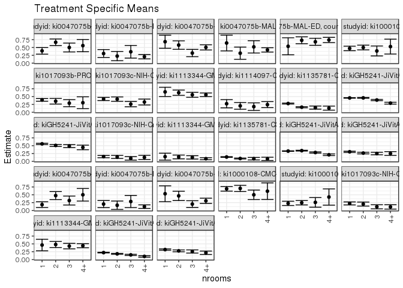

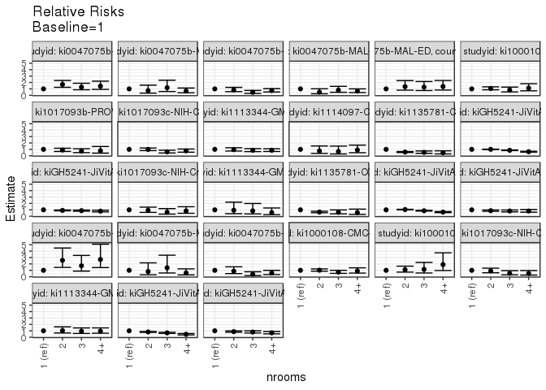

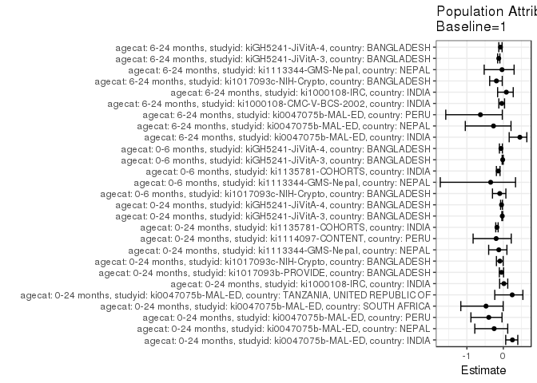

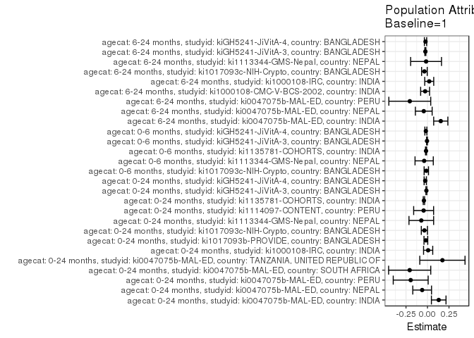

## Results Table

### Parameter: TSM

| agecat | studyid | country | intervention_level | baseline_level | estimate | ci_lower | ci_upper |
| --- | --- | --- | --- | --- | --- | --- | --- |
| 0-24 months | ki0047075b-MAL-ED | INDIA | 1 | NA | 0.3928571 | 0.2881932 | 0.4975211 |
| 0-24 months | ki0047075b-MAL-ED | INDIA | 2 | NA | 0.6666667 | 0.5618282 | 0.7715051 |
| 0-24 months | ki0047075b-MAL-ED | INDIA | 3 | NA | 0.5000000 | 0.3582499 | 0.6417501 |
| 0-24 months | ki0047075b-MAL-ED | INDIA | 4+ | NA | 0.5600000 | 0.3650046 | 0.7549954 |
| 0-24 months | ki0047075b-MAL-ED | NEPAL | 1 | NA | 0.3076923 | 0.1819804 | 0.4334042 |
| 0-24 months | ki0047075b-MAL-ED | NEPAL | 2 | NA | 0.2258065 | 0.0783098 | 0.3733031 |
| 0-24 months | ki0047075b-MAL-ED | NEPAL | 3 | NA | 0.3636364 | 0.1621966 | 0.5650761 |
| 0-24 months | ki0047075b-MAL-ED | NEPAL | 4+ | NA | 0.2061069 | 0.1366905 | 0.2755232 |
| 0-24 months | ki0047075b-MAL-ED | PERU | 1 | NA | 0.6842105 | 0.4748163 | 0.8936048 |
| 0-24 months | ki0047075b-MAL-ED | PERU | 2 | NA | 0.5769231 | 0.4423944 | 0.7114517 |
| 0-24 months | ki0047075b-MAL-ED | PERU | 3 | NA | 0.3225806 | 0.2060071 | 0.4391542 |
| 0-24 months | ki0047075b-MAL-ED | PERU | 4+ | NA | 0.5035971 | 0.4203251 | 0.5868692 |
| 0-24 months | ki0047075b-MAL-ED | SOUTH AFRICA | 1 | NA | 0.6428571 | 0.3913740 | 0.8943403 |
| 0-24 months | ki0047075b-MAL-ED | SOUTH AFRICA | 2 | NA | 0.3181818 | 0.1231725 | 0.5131911 |
| 0-24 months | ki0047075b-MAL-ED | SOUTH AFRICA | 3 | NA | 0.5200000 | 0.3237783 | 0.7162217 |
| 0-24 months | ki0047075b-MAL-ED | SOUTH AFRICA | 4+ | NA | 0.4234694 | 0.3541605 | 0.4927783 |
| 0-24 months | ki0047075b-MAL-ED | TANZANIA, UNITED REPUBLIC OF | 1 | NA | 0.5384615 | 0.2669251 | 0.8099979 |
| 0-24 months | ki0047075b-MAL-ED | TANZANIA, UNITED REPUBLIC OF | 2 | NA | 0.7301587 | 0.6203313 | 0.8399862 |
| 0-24 months | ki0047075b-MAL-ED | TANZANIA, UNITED REPUBLIC OF | 3 | NA | 0.6818182 | 0.5692234 | 0.7944130 |
| 0-24 months | ki0047075b-MAL-ED | TANZANIA, UNITED REPUBLIC OF | 4+ | NA | 0.7407407 | 0.6579262 | 0.8235553 |
| 0-24 months | ki1000108-IRC | INDIA | 1 | NA | 0.4702703 | 0.3982597 | 0.5422808 |
| 0-24 months | ki1000108-IRC | INDIA | 2 | NA | 0.5000000 | 0.4247465 | 0.5752535 |
| 0-24 months | ki1000108-IRC | INDIA | 3 | NA | 0.3888889 | 0.2294469 | 0.5483308 |
| 0-24 months | ki1000108-IRC | INDIA | 4+ | NA | 0.5294118 | 0.2918515 | 0.7669720 |
| 0-24 months | ki1017093b-PROVIDE | BANGLADESH | 1 | NA | 0.3944773 | 0.3519047 | 0.4370500 |
| 0-24 months | ki1017093b-PROVIDE | BANGLADESH | 2 | NA | 0.3518519 | 0.2617230 | 0.4419807 |
| 0-24 months | ki1017093b-PROVIDE | BANGLADESH | 3 | NA | 0.2903226 | 0.1772562 | 0.4033890 |
| 0-24 months | ki1017093b-PROVIDE | BANGLADESH | 4+ | NA | 0.3043478 | 0.1161668 | 0.4925288 |
| 0-24 months | ki1017093c-NIH-Crypto | BANGLADESH | 1 | NA | 0.4239130 | 0.3733896 | 0.4744365 |
| 0-24 months | ki1017093c-NIH-Crypto | BANGLADESH | 2 | NA | 0.4188482 | 0.3488332 | 0.4888632 |

[output cut: 78 more lines]

### Parameter: E(Y)

| agecat | studyid | country | intervention_level | baseline_level | estimate | ci_lower | ci_upper |
| --- | --- | --- | --- | --- | --- | --- | --- |
| 0-24 months | ki0047075b-MAL-ED | INDIA | NA | NA | 0.5234043 | 0.4594110 | 0.5873975 |
| 0-24 months | ki0047075b-MAL-ED | NEPAL | NA | NA | 0.2457627 | 0.1907167 | 0.3008088 |
| 0-24 months | ki0047075b-MAL-ED | PERU | NA | NA | 0.4889706 | 0.4294554 | 0.5484858 |
| 0-24 months | ki0047075b-MAL-ED | SOUTH AFRICA | NA | NA | 0.4357977 | 0.3750558 | 0.4965395 |
| 0-24 months | ki0047075b-MAL-ED | TANZANIA, UNITED REPUBLIC OF | NA | NA | 0.7120000 | 0.6557549 | 0.7682451 |
| 0-24 months | ki1000108-IRC | INDIA | NA | NA | 0.4779412 | 0.4294126 | 0.5264698 |
| 0-24 months | ki1017093b-PROVIDE | BANGLADESH | NA | NA | 0.3757143 | 0.3398113 | 0.4116172 |
| 0-24 months | ki1017093c-NIH-Crypto | BANGLADESH | NA | NA | 0.3878628 | 0.3531521 | 0.4225735 |
| 0-24 months | ki1113344-GMS-Nepal | NEPAL | NA | NA | 0.5780731 | 0.5385891 | 0.6175571 |
| 0-24 months | ki1114097-CONTENT | PERU | NA | NA | 0.2279070 | 0.1717046 | 0.2841094 |
| 0-24 months | ki1135781-COHORTS | INDIA | NA | NA | 0.2370674 | 0.2256958 | 0.2484389 |
| 0-24 months | kiGH5241-JiVitA-3 | BANGLADESH | NA | NA | 0.4438727 | 0.4363510 | 0.4513944 |
| 0-24 months | kiGH5241-JiVitA-4 | BANGLADESH | NA | NA | 0.5322521 | 0.5160648 | 0.5484394 |
| 0-6 months | ki1017093c-NIH-Crypto | BANGLADESH | NA | NA | 0.1385224 | 0.1139141 | 0.1631308 |
| 0-6 months | ki1113344-GMS-Nepal | NEPAL | NA | NA | 0.1112957 | 0.0861520 | 0.1364394 |
| 0-6 months | ki1135781-COHORTS | INDIA | NA | NA | 0.1217023 | 0.1128092 | 0.1305953 |
| 0-6 months | kiGH5241-JiVitA-3 | BANGLADESH | NA | NA | 0.3219971 | 0.3152345 | 0.3287596 |
| 0-6 months | kiGH5241-JiVitA-4 | BANGLADESH | NA | NA | 0.2864960 | 0.2726657 | 0.3003263 |
| 6-24 months | ki0047075b-MAL-ED | INDIA | NA | NA | 0.3402062 | 0.2733649 | 0.4070475 |
| 6-24 months | ki0047075b-MAL-ED | NEPAL | NA | NA | 0.1607143 | 0.1125109 | 0.2089177 |
| 6-24 months | ki0047075b-MAL-ED | PERU | NA | NA | 0.3275109 | 0.2665942 | 0.3884276 |
| 6-24 months | ki1000108-CMC-V-BCS-2002 | INDIA | NA | NA | 0.6631944 | 0.6085159 | 0.7178730 |
| 6-24 months | ki1000108-IRC | INDIA | NA | NA | 0.2462908 | 0.2002223 | 0.2923593 |
| 6-24 months | ki1017093c-NIH-Crypto | BANGLADESH | NA | NA | 0.1887097 | 0.1578857 | 0.2195336 |
| 6-24 months | ki1113344-GMS-Nepal | NEPAL | NA | NA | 0.4479167 | 0.4033837 | 0.4924496 |
| 6-24 months | kiGH5241-JiVitA-3 | BANGLADESH | NA | NA | 0.1969914 | 0.1889397 | 0.2050430 |
| 6-24 months | kiGH5241-JiVitA-4 | BANGLADESH | NA | NA | 0.2954018 | 0.2790421 | 0.3117615 |

### Parameter: RR

| agecat | studyid | country | intervention_level | baseline_level | estimate | ci_lower | ci_upper |
| --- | --- | --- | --- | --- | --- | --- | --- |
| 0-24 months | ki0047075b-MAL-ED | INDIA | 1 | 1 | 1.0000000 | 1.0000000 | 1.0000000 |
| 0-24 months | ki0047075b-MAL-ED | INDIA | 2 | 1 | 1.6969697 | 1.2454249 | 2.3122280 |
| 0-24 months | ki0047075b-MAL-ED | INDIA | 3 | 1 | 1.2727273 | 0.8625380 | 1.8779864 |
| 0-24 months | ki0047075b-MAL-ED | INDIA | 4+ | 1 | 1.4254545 | 0.9194820 | 2.2098537 |
| 0-24 months | ki0047075b-MAL-ED | NEPAL | 1 | 1 | 1.0000000 | 1.0000000 | 1.0000000 |
| 0-24 months | ki0047075b-MAL-ED | NEPAL | 2 | 1 | 0.7338710 | 0.3396388 | 1.5857040 |
| 0-24 months | ki0047075b-MAL-ED | NEPAL | 3 | 1 | 1.1818182 | 0.5937638 | 2.3522725 |
| 0-24 months | ki0047075b-MAL-ED | NEPAL | 4+ | 1 | 0.6698473 | 0.3944776 | 1.1374422 |
| 0-24 months | ki0047075b-MAL-ED | PERU | 1 | 1 | 1.0000000 | 1.0000000 | 1.0000000 |
| 0-24 months | ki0047075b-MAL-ED | PERU | 2 | 1 | 0.8431953 | 0.5738956 | 1.2388635 |
| 0-24 months | ki0047075b-MAL-ED | PERU | 3 | 1 | 0.4714640 | 0.2936208 | 0.7570252 |
| 0-24 months | ki0047075b-MAL-ED | PERU | 4+ | 1 | 0.7360266 | 0.5197843 | 1.0422306 |
| 0-24 months | ki0047075b-MAL-ED | SOUTH AFRICA | 1 | 1 | 1.0000000 | 1.0000000 | 1.0000000 |
| 0-24 months | ki0047075b-MAL-ED | SOUTH AFRICA | 2 | 1 | 0.4949495 | 0.2392150 | 1.0240786 |
| 0-24 months | ki0047075b-MAL-ED | SOUTH AFRICA | 3 | 1 | 0.8088889 | 0.4697167 | 1.3929699 |
| 0-24 months | ki0047075b-MAL-ED | SOUTH AFRICA | 4+ | 1 | 0.6587302 | 0.4310654 | 1.0066347 |
| 0-24 months | ki0047075b-MAL-ED | TANZANIA, UNITED REPUBLIC OF | 1 | 1 | 1.0000000 | 1.0000000 | 1.0000000 |
| 0-24 months | ki0047075b-MAL-ED | TANZANIA, UNITED REPUBLIC OF | 2 | 1 | 1.3560091 | 0.8011630 | 2.2951143 |
| 0-24 months | ki0047075b-MAL-ED | TANZANIA, UNITED REPUBLIC OF | 3 | 1 | 1.2662338 | 0.7448400 | 2.1526071 |
| 0-24 months | ki0047075b-MAL-ED | TANZANIA, UNITED REPUBLIC OF | 4+ | 1 | 1.3756614 | 0.8207049 | 2.3058765 |
| 0-24 months | ki1000108-IRC | INDIA | 1 | 1 | 1.0000000 | 1.0000000 | 1.0000000 |
| 0-24 months | ki1000108-IRC | INDIA | 2 | 1 | 1.0632184 | 0.8577795 | 1.3178601 |
| 0-24 months | ki1000108-IRC | INDIA | 3 | 1 | 0.8269476 | 0.5338346 | 1.2810006 |
| 0-24 months | ki1000108-IRC | INDIA | 4+ | 1 | 1.1257606 | 0.7007013 | 1.8086694 |
| 0-24 months | ki1017093b-PROVIDE | BANGLADESH | 1 | 1 | 1.0000000 | 1.0000000 | 1.0000000 |
| 0-24 months | ki1017093b-PROVIDE | BANGLADESH | 2 | 1 | 0.8919444 | 0.6754925 | 1.1777554 |
| 0-24 months | ki1017093b-PROVIDE | BANGLADESH | 3 | 1 | 0.7359677 | 0.4913018 | 1.1024761 |
| 0-24 months | ki1017093b-PROVIDE | BANGLADESH | 4+ | 1 | 0.7715217 | 0.4118701 | 1.4452270 |
| 0-24 months | ki1017093c-NIH-Crypto | BANGLADESH | 1 | 1 | 1.0000000 | 1.0000000 | 1.0000000 |
| 0-24 months | ki1017093c-NIH-Crypto | BANGLADESH | 2 | 1 | 0.9880521 | 0.8046737 | 1.2132208 |

[output cut: 78 more lines]

### Parameter: PAR

| agecat | studyid | country | intervention_level | baseline_level | estimate | ci_lower | ci_upper |
| --- | --- | --- | --- | --- | --- | --- | --- |
| 0-24 months | ki0047075b-MAL-ED | INDIA | 1 | NA | 0.1305471 | 0.0455863 | 0.2155079 |
| 0-24 months | ki0047075b-MAL-ED | NEPAL | 1 | NA | -0.0619296 | -0.1708759 | 0.0470167 |
| 0-24 months | ki0047075b-MAL-ED | PERU | 1 | NA | -0.1952399 | -0.3983716 | 0.0078917 |
| 0-24 months | ki0047075b-MAL-ED | SOUTH AFRICA | 1 | NA | -0.2070595 | -0.4520961 | 0.0379772 |
| 0-24 months | ki0047075b-MAL-ED | TANZANIA, UNITED REPUBLIC OF | 1 | NA | 0.1735385 | -0.0895725 | 0.4366495 |
| 0-24 months | ki1000108-IRC | INDIA | 1 | NA | 0.0076709 | -0.0456019 | 0.0609437 |
| 0-24 months | ki1017093b-PROVIDE | BANGLADESH | 1 | NA | -0.0187630 | -0.0405808 | 0.0030548 |
| 0-24 months | ki1017093c-NIH-Crypto | BANGLADESH | 1 | NA | -0.0360502 | -0.0718122 | -0.0002882 |
| 0-24 months | ki1113344-GMS-Nepal | NEPAL | 1 | NA | -0.0719269 | -0.2152286 | 0.0713748 |
| 0-24 months | ki1114097-CONTENT | PERU | 1 | NA | -0.0448203 | -0.1607321 | 0.0710915 |
| 0-24 months | ki1135781-COHORTS | INDIA | 1 | NA | -0.0414208 | -0.0492555 | -0.0335862 |
| 0-24 months | kiGH5241-JiVitA-3 | BANGLADESH | 1 | NA | -0.0128539 | -0.0180344 | -0.0076734 |
| 0-24 months | kiGH5241-JiVitA-4 | BANGLADESH | 1 | NA | -0.0261935 | -0.0392567 | -0.0131303 |
| 0-6 months | ki1017093c-NIH-Crypto | BANGLADESH | 1 | NA | -0.0136515 | -0.0390426 | 0.0117397 |
| 0-6 months | ki1113344-GMS-Nepal | NEPAL | 1 | NA | -0.0387043 | -0.1448520 | 0.0674433 |
| 0-6 months | ki1135781-COHORTS | INDIA | 1 | NA | -0.0169989 | -0.0230973 | -0.0109004 |
| 0-6 months | kiGH5241-JiVitA-3 | BANGLADESH | 1 | NA | -0.0056224 | -0.0105087 | -0.0007360 |
| 0-6 months | kiGH5241-JiVitA-4 | BANGLADESH | 1 | NA | -0.0190043 | -0.0305508 | -0.0074579 |
| 6-24 months | ki0047075b-MAL-ED | INDIA | 1 | NA | 0.1544919 | 0.0720921 | 0.2368917 |
| 6-24 months | ki0047075b-MAL-ED | NEPAL | 1 | NA | -0.0433673 | -0.1409311 | 0.0541964 |
| 6-24 months | ki0047075b-MAL-ED | PERU | 1 | NA | -0.2058224 | -0.4494273 | 0.0377825 |
| 6-24 months | ki1000108-CMC-V-BCS-2002 | INDIA | 1 | NA | -0.0275950 | -0.0794487 | 0.0242586 |
| 6-24 months | ki1000108-IRC | INDIA | 1 | NA | 0.0202634 | -0.0320698 | 0.0725966 |
| 6-24 months | ki1017093c-NIH-Crypto | BANGLADESH | 1 | NA | -0.0357801 | -0.0684560 | -0.0031043 |
| 6-24 months | ki1113344-GMS-Nepal | NEPAL | 1 | NA | -0.0163690 | -0.1957813 | 0.1630432 |
| 6-24 months | kiGH5241-JiVitA-3 | BANGLADESH | 1 | NA | -0.0246410 | -0.0307440 | -0.0185381 |
| 6-24 months | kiGH5241-JiVitA-4 | BANGLADESH | 1 | NA | -0.0231108 | -0.0362869 | -0.0099346 |

### Parameter: PAF

| agecat | studyid | country | intervention_level | baseline_level | estimate | ci_lower | ci_upper |
| --- | --- | --- | --- | --- | --- | --- | --- |
| 0-24 months | ki0047075b-MAL-ED | INDIA | 1 | NA | 0.2494193 | 0.0659104 | 0.3968765 |
| 0-24 months | ki0047075b-MAL-ED | NEPAL | 1 | NA | -0.2519894 | -0.7829702 | 0.1208617 |
| 0-24 months | ki0047075b-MAL-ED | PERU | 1 | NA | -0.3992877 | -0.8893583 | -0.0363339 |
| 0-24 months | ki0047075b-MAL-ED | SOUTH AFRICA | 1 | NA | -0.4751276 | -1.1668590 | -0.0042192 |
| 0-24 months | ki0047075b-MAL-ED | TANZANIA, UNITED REPUBLIC OF | 1 | NA | 0.2437338 | -0.2350190 | 0.5368990 |
| 0-24 months | ki1000108-IRC | INDIA | 1 | NA | 0.0160499 | -0.1019825 | 0.1214400 |
| 0-24 months | ki1017093b-PROVIDE | BANGLADESH | 1 | NA | -0.0499396 | -0.1097004 | 0.0066028 |
| 0-24 months | ki1017093c-NIH-Crypto | BANGLADESH | 1 | NA | -0.0929459 | -0.1893065 | -0.0043926 |
| 0-24 months | ki1113344-GMS-Nepal | NEPAL | 1 | NA | -0.1244253 | -0.4021484 | 0.0982893 |
| 0-24 months | ki1114097-CONTENT | PERU | 1 | NA | -0.1966605 | -0.8293799 | 0.2172231 |
| 0-24 months | ki1135781-COHORTS | INDIA | 1 | NA | -0.1747218 | -0.2079428 | -0.1424145 |
| 0-24 months | kiGH5241-JiVitA-3 | BANGLADESH | 1 | NA | -0.0289586 | -0.0407280 | -0.0173223 |
| 0-24 months | kiGH5241-JiVitA-4 | BANGLADESH | 1 | NA | -0.0492126 | -0.0742067 | -0.0248000 |
| 0-6 months | ki1017093c-NIH-Crypto | BANGLADESH | 1 | NA | -0.0985507 | -0.2973905 | 0.0698146 |
| 0-6 months | ki1113344-GMS-Nepal | NEPAL | 1 | NA | -0.3477612 | -1.7305515 | 0.3347643 |
| 0-6 months | ki1135781-COHORTS | INDIA | 1 | NA | -0.1396757 | -0.1901549 | -0.0913376 |
| 0-6 months | kiGH5241-JiVitA-3 | BANGLADESH | 1 | NA | -0.0174609 | -0.0327657 | -0.0023829 |
| 0-6 months | kiGH5241-JiVitA-4 | BANGLADESH | 1 | NA | -0.0663337 | -0.1073295 | -0.0268556 |
| 6-24 months | ki0047075b-MAL-ED | INDIA | 1 | NA | 0.4541126 | 0.1605507 | 0.6450136 |
| 6-24 months | ki0047075b-MAL-ED | NEPAL | 1 | NA | -0.2698413 | -1.0437105 | 0.2109955 |
| 6-24 months | ki0047075b-MAL-ED | PERU | 1 | NA | -0.6284444 | -1.5797140 | -0.0279556 |
| 6-24 months | ki1000108-CMC-V-BCS-2002 | INDIA | 1 | NA | -0.0416093 | -0.1230576 | 0.0339322 |
| 6-24 months | ki1000108-IRC | INDIA | 1 | NA | 0.0822743 | -0.1565426 | 0.2717774 |
| 6-24 months | ki1017093c-NIH-Crypto | BANGLADESH | 1 | NA | -0.1896040 | -0.3745591 | -0.0295358 |
| 6-24 months | ki1113344-GMS-Nepal | NEPAL | 1 | NA | -0.0365448 | -0.5255121 | 0.2956954 |
| 6-24 months | kiGH5241-JiVitA-3 | BANGLADESH | 1 | NA | -0.1250869 | -0.1563488 | -0.0946701 |
| 6-24 months | kiGH5241-JiVitA-4 | BANGLADESH | 1 | NA | -0.0782350 | -0.1237070 | -0.0346032 |